# Tugas Pertemuan 3 - Regresi dengan Peubah Lag

Studi Kasus: Kualitas Udara New Delhi (AQI vs O3)

Nama Mahasiswa - NIM

18 September 2026

# 1 Pendahuluan

Tugas ini merupakan penerapan materi **Pertemuan 3 - Regresi dengan Peubah Lag** pada data riil, yaitu data kualitas udara di New Delhi yang direkam per jam. Tiga pendekatan yang dipelajari diterapkan dan dibandingkan:

1. **Koyck Model** - meringkas pengaruh $X$ masa lalu yang tak terhingga ke dalam satu variabel $Y_{t-1}$.
2. **Distributed Lag Model (DLM)** - membatasi secara eksplisit berapa periode lag $X$ yang dilibatkan ($q$).
3. **Autoregressive Distributed Lag (ARDL)** - menggabungkan lag $X$ (p) dan lag $Y$ (q) sekaligus.

Peubah dependen ($Y$) adalah **AQI (Air Quality Index)**, dan peubah independen ($X$) dipilih dari salah satu polutan (CO, NO2, O3, PM10, PM2.5, atau SO2).

# 2 Persiapan Data

## 2.1 Packages

```r
library(dLagM)
library(dynlm)
library(MLmetrics)
library(lmtest)
library(car)
```

## 2.2 Impor Data

Pastikan file `NewDelhi_Air_quality.csv` berada pada folder kerja yang sama dengan file `.Rmd` ini (folder `Pertemuan-3` di GitHub).

```r
data <- read.csv("NewDelhi_Air_quality.csv")
str(data)
```

```
## 'data.frame':    72 obs. of  12 variables:
##  $ X              : int  0 1 2 3 4 5 6 7 8 9 ...
##  $ AQI            : num  30.2 28.2 26.6 25 26 26 26 24 23 24 ...
##  $ CO             : num  199 198 199 202 205 ...
##  $ datetime       : chr  "2022-10-21:18" "2022-10-21:19" "2022-10-21:20" "2022-10-21:21" ...
##  $ no2            : num  0.0469 0.0465 0.0469 0.0482 0.0489 ...
##  $ o3             : num  55.8 54.9 54.6 55.1 55.8 ...
##  $ pm10           : num  10.5 10.7 11.2 11.1 10.4 ...
##  $ pm25           : num  5.64 4.62 3.52 2.23 1.98 ...
##  $ so2            : num  0.387 0.41 0.402 0.376 0.339 ...
##  $ timestamp_local: chr  "2022-10-21T23:00:00" "2022-10-22T00:00:00" "2022-10-22T01:00:00" "2022-10-22T02:00:00" ...
##  $ timestamp_utc  : chr  "2022-10-21T18:00:00" "2022-10-21T19:00:00" "2022-10-21T20:00:00" "2022-10-21T21:00:00" ...
##  $ ts             : int  1666375200 1666378800 1666382400 1666386000 1666389600 1666393200 1666396800 1666400400 1666404000 1666407600 ...
```

```r
head(data)
```

```
##   X  AQI       CO      datetime        no2       o3      pm10     pm25
## 1 0 30.2 198.6027 2022-10-21:18 0.04685717 55.78995 10.486722 5.637410
## 2 1 28.2 197.6013 2022-10-21:19 0.04645554 54.93164 10.719325 4.618169
## 3 2 26.6 198.6027 2022-10-21:20 0.04685717 54.64554 11.155578 3.520902
## 4 3 25.0 201.9405 2022-10-21:21 0.04819594 55.07469 11.116206 2.225919
## 5 4 26.0 205.2784 2022-10-21:22 0.04886533 55.78995 10.405250 1.979471
## 6 5 26.0 208.6163 2022-10-21:23 0.05020411 56.50520  9.402518 1.792677
##         so2     timestamp_local       timestamp_utc         ts
## 1 0.3874302 2022-10-21T23:00:00 2022-10-21T18:00:00 1666375200
## 2 0.4097819 2022-10-22T00:00:00 2022-10-21T19:00:00 1666378800
## 3 0.4023313 2022-10-22T01:00:00 2022-10-21T20:00:00 1666382400
## 4 0.3762543 2022-10-22T02:00:00 2022-10-21T21:00:00 1666386000
## 5 0.3390014 2022-10-22T03:00:00 2022-10-21T22:00:00 1666389600
## 6 0.3129244 2022-10-22T04:00:00 2022-10-21T23:00:00 1666393200
```

Dataset berisi **72 observasi per jam** tanpa data hilang (`NA`), dengan kolom polutan: `CO`, `no2`, `o3`, `pm10`, `pm25`, `so2`, serta target `AQI`.

## 2.3 Pemilihan Peubah Independen (X)

Sebelum memodelkan, kita cek dahulu polutan mana yang paling berkaitan erat dengan AQI menggunakan korelasi Pearson sederhana:

```r
polutan <- c("CO", "no2", "o3", "pm10", "pm25", "so2")
korelasi <- sapply(data[, polutan], function(x) cor(data$AQI, x))
sort(korelasi, decreasing = TRUE)
```

```
##          o3          CO         no2        pm10        pm25         so2
##  0.97359901  0.79763320  0.73765472  0.08257568 -0.34665524 -0.74247813
```

**Interpretasi:** `O3` (ozon permukaan) memiliki korelasi tertinggi dengan AQI (r $\approx$ 0.97), jauh di atas polutan lainnya. Ini masuk akal karena pada rentang waktu perekaman data ini, sub-indeks ozon tampaknya menjadi kontributor dominan terhadap nilai AQI gabungan. Oleh karena itu, **O3 dipilih sebagai peubah independen (X)** pada seluruh pemodelan lag berikut.

## 2.4 Visualisasi Awal

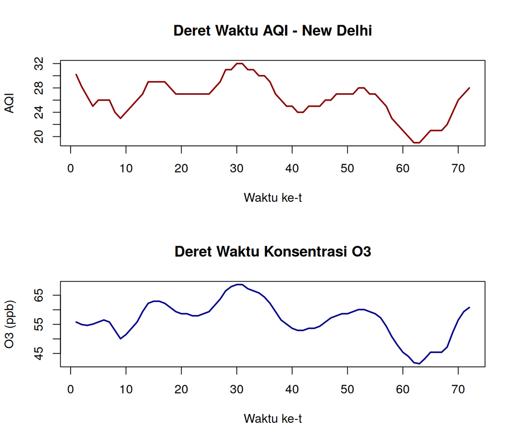

```r
par(mfrow = c(2, 1))
plot(data$AQI, type = "l", col = "darkred", lwd = 2,
     main = "Deret Waktu AQI - New Delhi", ylab = "AQI", xlab = "Waktu ke-t")
plot(data$o3, type = "l", col = "darkblue", lwd = 2,
     main = "Deret Waktu Konsentrasi O3", ylab = "O3 (ppb)", xlab = "Waktu ke-t")
```

```r
par(mfrow = c(1, 1))
```

Kedua deret menunjukkan pola naik-turun yang searah (mengikuti siklus harian radiasi matahari yang memicu reaksi fotokimia ozon), mendukung hasil korelasi yang tinggi di atas.

## 2.5 Pembagian Data Latih dan Uji

Mengikuti rasio pada modul (75% : 25%), dari 72 observasi kita gunakan **54 data pertama untuk training** dan **18 data terakhir untuk testing**.

```r
df <- data.frame(Yt = data$AQI, Xt = data$o3)

n_train <- 54
train <- df[1:n_train, ]
test  <- df[(n_train + 1):nrow(df), ]

train.ts <- ts(train)
test.ts  <- ts(test)
data.ts  <- ts(df)

nrow(train); nrow(test)
```

```
## [1] 54
```

```
## [1] 18
```

# 3 Model Koyck

## 3.1 Pemodelan

```r
model.koyck <- koyckDlm(x = train$Xt, y = train$Yt)
summary(model.koyck)
```

```
##
## Call:
## "Y ~ (Intercept) + Y.1 + X.t"
##
## Residuals:
##       Min        1Q    Median        3Q       Max
## -1.135845 -0.266174  0.005908  0.250093  1.063969
##
## Coefficients:
##             Estimate Std. Error t value Pr(>|t|)
## (Intercept)  0.61475    0.92829   0.662    0.511
## Y.1          0.40694    0.07979   5.100 5.25e-06 ***
## X.t          0.26339    0.03991   6.600 2.54e-08 ***
## ---
## Signif. codes:  0 '***' 0.001 '**' 0.01 '*' 0.05 '.' 0.1 ' ' 1
##
## Residual standard error: 0.5015 on 50 degrees of freedom
## Multiple R-Squared: 0.9489,  Adjusted R-squared: 0.9468
## Wald test: 423.5 on 2 and 50 DF,  p-value: < 2.2e-16
##
## Diagnostic tests:
## NULL
##
##                             alpha      beta       phi
## Geometric coefficients:  1.036564 0.2633856 0.4069377
```

**Catatan teknis:** `koyckDlm()` pada `dLagM` mengestimasi model ini dengan **regresi variabel instrumen (IV/2SLS)**, bukan OLS biasa, karena $Y_{t-1}$ pada model Koyck berkorelasi dengan error gabungan $V_t$ (masalah endogenitas). $X_{t-1}$ digunakan sebagai instrumen untuk $Y_{t-1}$.

**Interpretasi:** P-value dari `X.t` dan `Y.1` keduanya < 0.05, artinya konsentrasi O3 saat ini maupun AQI periode sebelumnya sama-sama berpengaruh signifikan terhadap AQI saat ini. Koefisien $\lambda$ (pada `Y.1`) sebesar **0.407** menunjukkan tingkat penurunan pengaruh (decay rate) O3 masa lalu terhadap AQI.

Persamaan model:
$$\hat{Y_t} = 0.6148 +
0.2634X_t + 0.4069Y_{t-1}$$

## 3.2 Uji Asumsi

```r
# 1. Autokorelasi -> gunakan Breusch-Godfrey (bukan Durbin-Watson) karena
#    model memuat peubah dependen ber-lag (Y.1) sebagai prediktor
bgtest(model.koyck$model, order = 2)
```

```
##
##  Breusch-Godfrey test for serial correlation of order up to 2
##
## data:  model.koyck$model
## LM test = 0.10115, df = 2, p-value = 0.9507
```

```r
# 2. Heteroskedastisitas
bptest(model.koyck$model)
```

```
##
##  studentized Breusch-Pagan test
##
## data:  model.koyck$model
## BP = 22.148, df = 2, p-value = 1.551e-05
```

```r
# 3. Normalitas sisaan
shapiro.test(residuals(model.koyck$model))
```

```
##
##  Shapiro-Wilk normality test
##
## data:  residuals(model.koyck$model)
## W = 0.9844, p-value = 0.7136
```

**Interpretasi (H0 ditolak jika P-value < 0.05):**

- **Autokorelasi (Breusch-Godfrey):** LM = 0.101, P-value = 0.951 → gagal tolak H0, **tidak ada autokorelasi** pada sisaan.
- **Heteroskedastisitas (Breusch-Pagan):** BP = 22.15, P-value = 1.55e-05 → tolak H0, **ragam sisaan tidak homogen** (heteroskedastisitas). Ini kelemahan model Koyck di kasus ini.
- **Normalitas (Shapiro-Wilk):** W = 0.984, P-value = 0.714 → gagal tolak H0, **sisaan menyebar normal**. Menariknya, dari ketiga model pada tugas ini, justru Koyck yang paling memenuhi asumsi normalitas.

## 3.3 Peramalan

```r
fore.koyck <- forecast(model = model.koyck, x = test$Xt, h = nrow(test))
fore.koyck
```

```
## $forecasts
##  [1] 27.04989 26.69341 25.79480 24.48718 23.20150 22.01896 21.16096 20.24664
##  [9] 19.78038 20.06161 20.74121 21.01777 21.13031 21.64708 23.17609 24.92863
## [17] 26.39536 27.36900
##
## $call
## forecast.koyckDlm(model = model.koyck, x = test$Xt, h = nrow(test))
##
## attr(,"class")
## [1] "forecast.koyckDlm" "dLagM"
```

```r
mape.koyck <- MAPE(fore.koyck$forecasts, test$Yt)
dev.koyck  <- sum(residuals(model.koyck$model)^2)   # SSR (deviance) model latih
cat("MAPE Model Koyck    :", mape.koyck, "\n")
```

```
## MAPE Model Koyck    : 0.03065559
```

```r
cat("Deviance Model Koyck:", dev.koyck, "\n")
```

```
## Deviance Model Koyck: 12.57627
```

MAPE $\approx$ **3.07%** - akurasi peramalan sudah cukup baik, namun paling rendah dibanding dua model berikutnya.

# 4 Model Regresi dengan Peubah Lag (DLM)

## 4.1 Penentuan Lag Optimum

```r
finiteDLMauto(formula = Yt ~ Xt, data = data.frame(train),
              q.min = 1, q.max = 10,
              model.type = "dlm", error.type = "AIC", trace = TRUE)
```

```
##    q - k    MASE      AIC      BIC     GMRAE   MBRAE R.Adj.Sq  Ljung-Box
## 10    10 0.34979 20.07730 43.27177 19294.937 0.50284  0.98413 0.43913084
## 5      5 0.39523 27.56666 42.70123 10735.733 0.50361  0.98256 0.15878289
## 3      3 0.41283 27.57546 39.16641  9505.636 0.50323  0.98199 0.09927070
## 4      4 0.41370 28.43184 41.81600 12815.760 0.50720  0.98184 0.14711370
## 9      9 0.39535 29.19717 50.87712 16561.703 0.51188  0.98117 0.97461829
## 6      6 0.39272 30.20446 47.04527  8064.222 0.49280  0.98198 0.16852073
## 8      8 0.41678 30.97603 51.09108 14902.811 0.52236  0.98166 0.38628391
## 7      7 0.40855 31.46561 49.96708  9938.515 0.49890  0.98187 0.26820909
## 2      2 0.44552 46.15758 55.91379  9550.642 0.49722  0.97353 0.07947546
## 1      1 0.52453 87.92883 95.81000  8966.830 0.41820  0.94072 0.18599697
```

**Interpretasi:** AIC turun tajam dari $q=1$ (87.9) sampai $q=3$ (27.6), lalu berosilasi datar pada kisaran 27-31 hingga $q=9$, dan baru turun lagi di batas atas pencarian ($q=10$, AIC=20.1). Penurunan di ujung rentang ($q=10$) berisiko **overfitting** karena jumlah parameter (12) sudah cukup besar relatif terhadap 54 data latih. Karena itu, **q = 3 dipilih sebagai lag optimum** yang lebih parsimoni dan stabil (AIC-nya sudah sangat dekat dengan titik-titik lain di sekitarnya).

## 4.2 Pemodelan dengan Lag Optimum (q = 3)

```r
model.dlm.opt <- dlm(x = train$Xt, y = train$Yt, q = 3)
summary(model.dlm.opt)
```

```
##
## Call:
## lm(formula = model.formula, data = design)
##
## Residuals:
##      Min       1Q   Median       3Q      Max
## -0.45509 -0.33197 -0.00225  0.27891  0.37956
##
## Coefficients:
##             Estimate Std. Error t value Pr(>|t|)
## (Intercept) -0.41298    0.63454  -0.651    0.518
## x.t          0.46019    0.04916   9.361 3.18e-12 ***
## x.1          0.05634    0.10444   0.539    0.592
## x.2         -0.07692    0.10449  -0.736    0.465
## x.3          0.02841    0.04897   0.580    0.565
## ---
## Signif. codes:  0 '***' 0.001 '**' 0.01 '*' 0.05 '.' 0.1 ' ' 1
##
## Residual standard error: 0.2968 on 46 degrees of freedom
## Multiple R-squared:  0.9834, Adjusted R-squared:  0.982
## F-statistic: 682.7 on 4 and 46 DF,  p-value: < 2.2e-16
##
## AIC and BIC values for the model:
##        AIC      BIC
## 1 27.57546 39.16641
```

**Interpretasi:** Hanya `x.t` (O3 saat ini) yang signifikan (P-value < 0.001); ketiga lag O3 sebelumnya (x.1, x.2, x.3) tidak signifikan secara individual. Ini konsisten dengan sifat ozon yang bereaksi cepat terhadap kondisi atmosfer saat ini. Model ini memberikan $R^2 = 0.983$, naik cukup jauh dibanding Koyck.

## 4.3 Uji Asumsi

```r
bgtest(model.dlm.opt$model, order = 2)
```

```
##
##  Breusch-Godfrey test for serial correlation of order up to 2
##
## data:  model.dlm.opt$model
## LM test = 2.939, df = 2, p-value = 0.23
```

```r
dwtest(model.dlm.opt$model)     # valid karena tidak ada lag Y sebagai prediktor
```

```
##
##  Durbin-Watson test
##
## data:  model.dlm.opt$model
## DW = 2.3832, p-value = 0.857
## alternative hypothesis: true autocorrelation is greater than 0
```

```r
bptest(model.dlm.opt$model)
```

```
##
##  studentized Breusch-Pagan test
##
## data:  model.dlm.opt$model
## BP = 5.0993, df = 4, p-value = 0.2773
```

```r
shapiro.test(residuals(model.dlm.opt$model))
```

```
##
##  Shapiro-Wilk normality test
##
## data:  residuals(model.dlm.opt$model)
## W = 0.85738, p-value = 2.094e-05
```

**Interpretasi:**

- **Autokorelasi:** Breusch-Godfrey P-value = 0.230 dan Durbin-Watson P-value = 0.857 (DW = 2.38) → **tidak ada autokorelasi**.
- **Heteroskedastisitas:** Breusch-Pagan P-value = 0.277 → **ragam sisaan homogen**.
- **Normalitas:** Shapiro-Wilk P-value = 2.1e-05 → **sisaan TIDAK menyebar normal**.

Model DLM optimum lolos uji autokorelasi dan homoskedastisitas, namun sisaan belum menyebar normal. Perhatikan pula peringatan *multicollinearity* yang lazim muncul pada model ini karena `x.t`, `x.1`, `x.2`, `x.3` saling berkorelasi tinggi.

## 4.4 Peramalan

```r
fore.dlm.opt <- forecast(model = model.dlm.opt, x = test$Xt, h = nrow(test))
fore.dlm.opt
```

```
## $forecasts
##  [1] 27.00759 26.36400 25.00150 23.28426 21.94559 20.82617 20.14530 19.18853
##  [9] 18.94198 19.86911 20.92387 20.89707 20.78282 21.66665 24.07145 26.19090
## [17] 27.41499 28.04662
##
## $call
## forecast.dlm(model = model.dlm.opt, x = test$Xt, h = nrow(test))
##
## attr(,"class")
## [1] "forecast.dlm" "dLagM"
```

```r
mape.dlm.opt <- MAPE(fore.dlm.opt$forecasts, test$Yt)
dev.dlm.opt  <- sum(residuals(model.dlm.opt$model)^2)
cat("MAPE Model DLM Optimum    :", mape.dlm.opt, "\n")
```

```
## MAPE Model DLM Optimum    : 0.006978447
```

```r
cat("Deviance Model DLM Optimum:", dev.dlm.opt, "\n")
```

```
## Deviance Model DLM Optimum: 4.052564
```

MAPE turun jauh menjadi $\approx$ **0.70%**, jauh lebih baik dari Koyck.

# 5 Model Autoregressive Distributed Lag (ARDL)

## 5.1 Penentuan Lag Optimum

Ingat notasi pada `dLagM`: **p** = panjang lag $X$, **q** = panjang lag $Y$. Pencarian dibatasi hingga `max.p = 6` dan `max.q = 6` agar sebanding dengan rentang pencarian DLM dan menghindari kombinasi lag ekstrem yang berisiko overfitting pada 54 data latih.

```r
model.ardl.opt <- ardlBoundOrders(data = data.frame(train), ic = "AIC",
                                   formula = Yt ~ Xt, max.p = 6, max.q = 6)
model.ardl.opt$p   # lag X (p) optimum
```

```
##   Xt
## 1  2
```

```r
model.ardl.opt$q   # lag Y (q) optimum
```

```
## [1] 1
```

```r
model.ardl.opt$min.Stat
```

```
## [1] 26.91458
```

```r
round(model.ardl.opt$Stat.table, 2)
```

```
##       q = 1 q = 2 q = 3 q = 4 q = 5 q = 6
## p = 1 42.20 26.93 29.45 31.61 31.49 32.39
## p = 2 26.91 28.84 31.44 33.21 32.76 32.93
## p = 3 31.52 31.52 33.44 35.19 34.76 32.00
## p = 4 31.09 32.72 32.72 32.64 35.04 33.84
## p = 5 33.13 34.44 35.41 35.41 36.78 35.12
## p = 6 32.76 34.42 33.08 35.07 35.07 37.07
```

**Interpretasi:** Kombinasi lag terbaik adalah **p = 2** (lag O3) dan **q = 1** (lag AQI), dengan AIC terendah $\approx$ 26.91 di antara seluruh kombinasi $p,q \in \{1,...,6\}$ yang diuji.

## 5.2 Pemodelan dengan Lag Optimum

```r
model.ardl.final <- ardlDlm(formula = Yt ~ Xt, data = train, p = 2, q = 1)
summary(model.ardl.final)
```

```
##
## Time series regression with "ts" data:
## Start = 3, End = 54
##
## Call:
## dynlm(formula = as.formula(model.text), data = data)
##
## Residuals:
##      Min       1Q   Median       3Q      Max
## -0.65492 -0.34427  0.00089  0.29247  0.88484
##
## Coefficients:
##              Estimate Std. Error t value Pr(>|t|)
## (Intercept) -0.140118   0.697082  -0.201   0.8416
## Xt.t         0.475785   0.056196   8.467 5.17e-11 ***
## Xt.1        -0.090562   0.112690  -0.804   0.4257
## Xt.2        -0.007052   0.055725  -0.127   0.8998
## Yt.1         0.185244   0.093465   1.982   0.0533 .
## ---
## Signif. codes:  0 '***' 0.001 '**' 0.01 '*' 0.05 '.' 0.1 ' ' 1
##
## Residual standard error: 0.3462 on 47 degrees of freedom
## Multiple R-squared:  0.977,  Adjusted R-squared:  0.9751
## F-statistic: 499.4 on 4 and 47 DF,  p-value: < 2.2e-16
```

**Interpretasi:** Selain `Xt.t` (O3 saat ini, sangat signifikan), lag AQI satu periode sebelumnya (`Yt.1`) juga mendekati signifikan (P-value = 0.053, marjinal pada taraf 5%), dengan koefisien **positif** (0.185) — mengindikasikan sedikit *persistence* pada AQI dari satu jam ke jam berikutnya, di luar pengaruh langsung O3.

## 5.3 Uji Asumsi

```r
bgtest(model.ardl.final$model, order = 2)
```

```
##
##  Breusch-Godfrey test for serial correlation of order up to 2
##
## data:  model.ardl.final$model
## LM test = 16.235, df = 2, p-value = 0.0002983
```

```r
bptest(model.ardl.final$model)
```

```
##
##  studentized Breusch-Pagan test
##
## data:  model.ardl.final$model
## BP = 27.834, df = 4, p-value = 1.348e-05
```

```r
shapiro.test(residuals(model.ardl.final$model))
```

```
##
##  Shapiro-Wilk normality test
##
## data:  residuals(model.ardl.final$model)
## W = 0.92561, p-value = 0.003042
```

**Interpretasi:**

- **Autokorelasi:** Breusch-Godfrey LM = 16.24, P-value = 0.0003 → tolak H0, **terdapat autokorelasi** pada sisaan.
- **Heteroskedastisitas:** Breusch-Pagan BP = 27.83, P-value = 1.35e-05 → tolak H0, **ragam sisaan tidak homogen**.
- **Normalitas:** Shapiro-Wilk P-value = 0.003 → tolak H0, **sisaan TIDAK menyebar normal**.

**Catatan penting:** meskipun model ARDL(2,1) memberikan MAPE terkecil (lihat bagian Peramalan), ternyata model ini **gagal memenuhi dua asumsi penting sekaligus** (autokorelasi dan homoskedastisitas). Ini adalah temuan yang wajar terjadi: model dengan fit/akurasi terbaik belum tentu model yang paling valid secara inferensial. Kemungkinan penyebabnya adalah pola musiman/siklik harian pada AQI dan O3 yang belum sepenuhnya tertangkap oleh kombinasi lag pendek ini.

## 5.4 Peramalan

```r
fore.ardl.final <- forecast(model = model.ardl.final, x = test$Xt, h = nrow(test))
fore.ardl.final
```

```
## $forecasts
##  [1] 26.96672 26.34976 25.00884 23.32808 21.99955 20.84669 20.19940 19.20577
##  [9] 19.05597 19.92651 20.94928 20.93181 20.91344 21.76081 24.13800 26.15417
## [17] 27.46493 28.09899
##
## $call
## forecast.ardlDlm(model = model.ardl.final, x = test$Xt, h = nrow(test))
##
## attr(,"class")
## [1] "forecast.ardlDlm" "dLagM"
```

```r
mape.ardl.final <- MAPE(fore.ardl.final$forecasts, test$Yt)
dev.ardl.final  <- sum(residuals(model.ardl.final$model)^2)
cat("MAPE Model ARDL(2,1)    :", mape.ardl.final, "\n")
```

```
## MAPE Model ARDL(2,1)    : 0.006507536
```

```r
cat("Deviance Model ARDL(2,1):", dev.ardl.final, "\n")
```

```
## Deviance Model ARDL(2,1): 5.631836
```

MAPE $\approx$ **0.65%**, sedikit lebih kecil dari DLM, namun perlu dibaca bersama hasil uji asumsi di atas.